# 1 Introduction

# 2 Climate policy in Finland

In this chapter, I will provide a short introduction to the climate policy in Finland before the implementation of the European Union emission trading system and a brief introduction of the different phases of the European Union emission trading system. The effects of these regulatory updates are discussed in the following chapter, but a short synopsis of the regulatory evolution is necessary for the reader to fully appreciate the economic consequences of the policy shocks produced by said institutions.

## 2.1 Prior to EU Emission trading system

Finland was the first country in the world to implement a tax on the sources of carbon emissions . The tax encompassed various emission sources, as it targeted both transport fuels and fuels used for energy production . The carbon tax was stringent as it was indifferent to the final user and buyer, whether household or industrial, of the energy-producing fuels . Only fuel source exempted from this tax was wood . The tax was initially modest with a relatively low valuation of 1.12 € per CO2 equivalent tonne and the tax was progressively increased to a more substantial level . Sweden closely followed the Finnish example and enacted carbon tax in 1991 . The effectiveness of the Finnish and Swedish carbon taxes will be discussed in the next chapter where I will further discuss the literature and the evidence of the effectiveness of different policy choices.

Carbon tax was not implemented as a revenue raising measure, as it was from the beginning argued from environmental grounds as it could price the externalities cause by the burning of fossil fuels. The government proposal that was enacted as law in 1989 and entered into force in the beginning of 1990. . The effects of these early carbon taxes are not in the scope of this thesis, but they might be the answer to my counterintuitive findings of the reaction of the Finnish economy to the carbon policy shocks of European Union. Finnish economy had more time and a solid monetary incentive to use the fossil fuel resources more efficiently and to invest to green infrastructure prior to the enaction of the European Union emission trading system when comparing to other European economies which did not have such incentives. Even after that the tax continues to affect the sectors that are not subject to the European union emission trading system.

## 2.2 EU emission trading system

The second chapter of Finnish climate policy began in 2005 as the European Union emission trading system (ETS) was established. The ETS is based on a cap-and-trade scheme that restricts the total emissions for the entire affected sectors (these will vary in the different phases) and lets the market participants trade with each other . Also, various allocation schemes have been implemented in the different phases of the EU ETS as the allocation strategy has been updated . The ETS has been operating in four phases: Phase I ran from 2005 to 2007 and served as an experimentation period, Phase II operated from 2008 to 2012, Phase III from 2013 to 2020, and Phase IV will run from 2021 to 2030 .

Phase I of EU ETS was widely considered the experimentation period where the institutions of ETS were tested; also, in the first two phases, the national governments were left in charge to plan the allocation of these certificates to their respective industries . These national allocation plans (NAP) were then put under the scrutiny of the European Commission . The verification procedure of the NAPs will be a significant source of the carbon policy surprise, which is discussed in chapter 4.

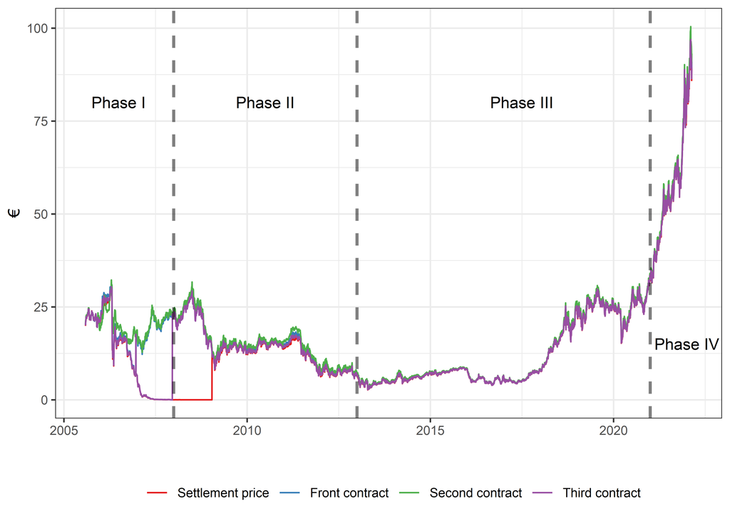

Figure 2.1: The evolution of the EU Emission trading system spot price and different future lengths prices through the different phases of the system.

The oversupply of ETS allowances in late Phase II led to the reforms in Phase III. The most substantial updates to the ETS were the abolition of the NAP and the resulting centralisation of the system by adopting a single EU-wide cap. This cap was planned to reduce yearly by a linear amount that was decided to be 1.74 per cent of the year 2010 total allowances. . This linear decrease would lead to a total of 21 per cent reduction by 2020 in emissions in the markets governed by the ETS when compared to the levels in 2005 . Another major reform enacted in Phase III was the phasing out of the free allocation to the energy sector in 2013 and plans of enacting this also to the remaining industrial sectors by 2027 . The effects of these strict system overhauls can also be seen in figure 1, where the news of future updates can be seen moving the price of futures before it is realised at the spot price of the allowances. This is the essence behind the carbon policy surprise series and its usefulness in identifying the structural shocks in the SVAR model in chapter 5.

The changes brought by the Phase IV of the European Union ETS can be characterised by a more ambitious pace of allowance reductions and more stringent rules for the free allocations in the remaining sectors that still had them . This ambitious pace was countervailed by diverting the auction revenues to be used to support energy sector modernisation by the innovation fund and modernisation fund . As Phase IV has only recently begun, the full implications of the rule changes are yet to be seen. Another dimension that will test the resolve of the European decision-makers is higher energy costs and the effects of those on their constituents.